# The Effect of Vitamin C on Tooth Growth in Guinea Pigs

JRB

September 16, 2016

## Introduction

We propose to analyze the length of odontoblasts for 60 guinea pigs that have received one of three dose levels of Vitamin C by of of two delivery methods (orange juice OJ) or ascorbic acid (VC). We will first perform some exploratory data analysis to generate some hypothesis that we will be statistically tested.

## Exploratory Data Analysis

We fill first plot the data set to represent the density of observations and some key statistics for each combination of delivery method at each dose level. The graph will compare side by side the tooth length for dose level for both OJ and VC.

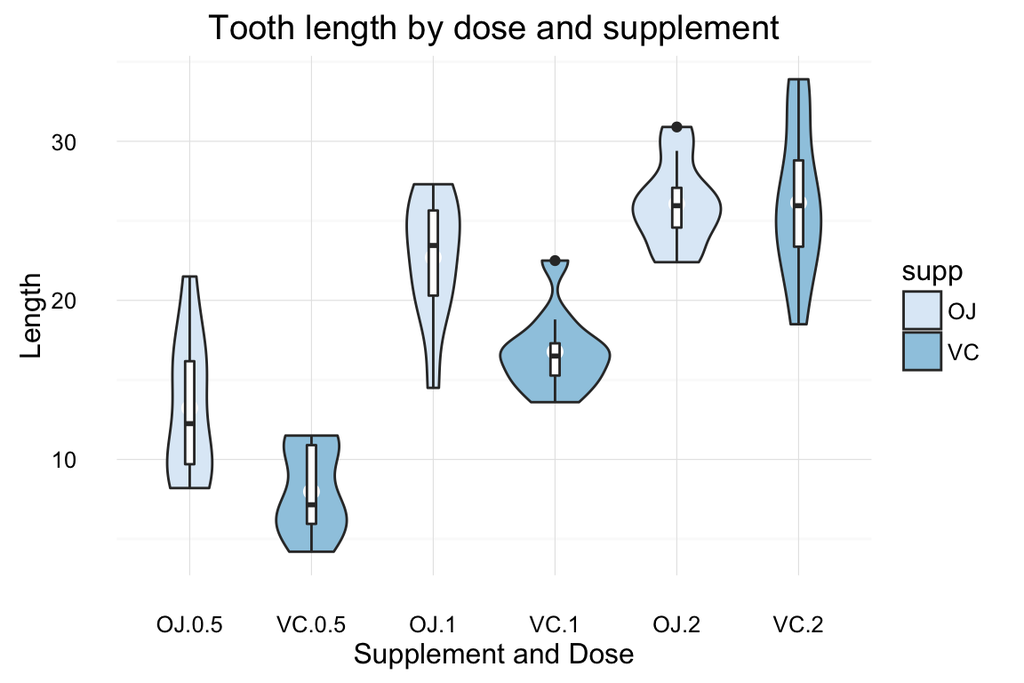

The figure illustrates that increasing doses of vitamin C would correspond to longer teeth and that the mean of admistration could impact tooth growth also. Table 1 provides a summary of the `ToothGrowth` data set.

From the summary table we can formulate the following hypothesis that could be submitted to a statistical testing. The hypothesis are:

1. Tooth length increases as dose increases
2. Mean of delivery has an impact on tooth growth

Summary Statistics for tooth length by dose and supplement

| dose | supp | n | Mean | Std.Dev | Sample Error |
| --- | --- | --- | --- | --- | --- |
| 0.5 | OJ | 10 | 13.23 | 4.46 | 1.41 |
| 0.5 | VC | 10 | 7.98 | 2.75 | 0.87 |
| 1.0 | OJ | 10 | 22.70 | 3.91 | 1.24 |
| 1.0 | VC | 10 | 16.77 | 2.52 | 0.80 |
| 2.0 | OJ | 10 | 26.06 | 2.66 | 0.84 |
| 2.0 | VC | 10 | 26.14 | 4.80 | 1.52 |

## Inference

### Hypothesis 1: “Tooth length increases as dose increases”

To test this hypothesis, we will compare tooth length means at different dose levels (regardless of mean of administration). We will test the null hypothesis that the samples are drawn from populations of the same mean.

#### *Example: Test 1: 0.5 mg vs 1 mg*

This section explains our general methodology for hypothesis testing. All results will be summarized in table 2. $\mu_1$ is the mean of tooth length for the 1 mg group  
$\mu_2$ is the mean of tooth length for the 0.5 mg group $H_0: \mu_1=\mu_2$  
$H_3: \mu_1>\mu_2$

First we will calculate our t-statistics (TS) using the R `t.test` function. For our statistical test we assume an unequal variance and a single sided test. We will reject $H_0$ if $TS \geqslant t_{0.95}$, the $t_{0.95}$ is calculated using 37.99 as the degree of freedom for unequal variances and provided by the `t.test` function. $t_{0.95}=$ 1.69. TS is also provided by the R `t.test` function: TS= 6.48. We do have $TS \geqslant t_{0.95}$, and we therefore reject our null hypothesis in favor of the alternate. We conlcude that tooth length is on average greater for the 1mg dose than for the 0.5 mg dose with a 95% confidence. The t-test is summarized in the table below.

Welch Two Sample t-test: `D1$len` and `D0.5$len`

| Test statistic | df | P value | Alternative hypothesis |
| --- | --- | --- | --- |
| 6.5 | 38 | 0 * * * | greater |

|  | Test 1: 0.5 vs 1 mg | Test 2: 1 vs 2 mg | Test 3: 0.5 vs 2 mg |
| --- | --- | --- | --- |
| **statistic** | 6.476648 | 4.900484 | 11.79905 |
| **parameter** | 37.98641 | 37.10109 | 36.88259 |
| **p.value** | 6.341504e-08 | 9.532148e-06 | 2.198762e-14 |

As the previous table show, in all cases the Test Statistics is over the t-value for 0.95 (~ 1.69) and the appropriate degree of freedom. We can appropriately reject $H_0$. There’s a difference in the mean and higer doses have a higher mean than lower doses.

### Hypothesis 2: Mean of delivery has an impact on tooth growth

#### *Impact of mean of administration on tooth growth across all dose groups*

$\mu_1$ is the mean of tooth length for the OJ group  
$\mu_2$ is the mean of tooth length for the VC group

$H_0: \mu_1=\mu_2$  
$H_3: \mu_1>\mu_2$

Welch Two Sample t-test: `len` by `supp`

| Test statistic | df | P value | Alternative hypothesis |
| --- | --- | --- | --- |
| 1.9 | 55 | 0.03 * | greater |

The t-value ($t_{0.95}$) with 55.3094327 degree of freedom is 1.67. The $t_{0.95}$ value is les than the test statistics so we can reject the null hypothesis. There’s a difference in mean for tooth length by mean of administration across dose groups.  
*Conclusion* When analyzed across dose groups the mean of administration does have an impact on tooth growth. We will now refine our analysis and look at the tooth length mean differences at each dose level comparing the two means of administration.

#### *Mean of admistration impact at 0.5 mg*

$\mu_1$ is the mean of tooth length for the OJ group at the analysed dose level  
$\mu_2$ is the mean of tooth length for the VC group at the analysed dose level

$H_0: \mu_1=\mu_2$ $H_3: \mu_1>\mu_2$

Welch Two Sample t-test: `len` by `supp`

| Test statistic | df | P value | Alternative hypothesis |
| --- | --- | --- | --- |
| 3.2 | 15 | 0 * * | greater |

The t-value ($t_{0_95}$) with degree of freedom is 1.7532907. The $t_{0.95}$ value is lower than the test statistics so we can reject the null hypothesis. There’s a difference in mean for toothength by mean of administration at the 0.5 mg dose level.  
*Conclusion* At the 0.5mg dose level, OJ has a greater mean tooth length than VC. At this dose level the mode of administration has an impact on tooth growth.

#### *Mean of admistration impact at 1mg*

$\mu_1$ is the mean of tooth length for the OJ group at the analysed dose level  
$\mu_2$ is the mean of tooth length for the VC group at the analysed dose level

$H_0: \mu_1=\mu_2$ $H_3: \mu_1>\mu_2$

Welch Two Sample t-test: `len` by `supp`

[output not shown]

The t-value ($t_{0_95}$) with degree of freedom is 1.7503732. The $t_{0.95}$ value is lower than the test statistics so we can reject the null hypothesis. There’s a difference in mean for toothength by mean of administration at the 1 mg dose level.  
*Conclusion* At the 1mg dose level, OJ has a greater mean tooth length than VC. At this dose level the mode of administration has an impact on tooth growth.

#### *Mean of admistration impact at 2mg*

$\mu_1$ is the mean of tooth length for the OJ group at the analysed dose level  
$\mu_2$ is the mean of tooth length for the VC group at the analysed dose level

$H_0: \mu_1=\mu_2$ $H_3: \mu_1>\mu_2$

Welch Two Sample t-test: `len` by `supp`

[output not shown]

## Conclusion and notes on assupmtions

During our analysis we assumed that the samples were iid, the sample variances were considered unequal and we used a confidence level of 95% for all statistical testing. With the statistical rigor of our hypothesis testing we can conclude that:  
* As the dose of vitamin C increases so does the length of the tooth. Vitamin C has a positive impact on the tooth growth of guinea pig  
* The mean of admnistration Orange Juice or Ascorbic Acid has an impact on two growth overall. The impact is measurable for the lower dose groups (0.5mg and 1mg) and favors orange juice over ascorbic acid

# Appendix

## Additional Summary Tables

From Table 1, we can make the observation that tooth length mean varies by supplement type, the mean is greater for OJ. We will test the hypothesis that the mean observed length of OJ is greater than the mean observed length for VC. So, our hypothesis testing should determine if there’s a statistically significant effect of supplement on tooth length.  
***

Summary statistics for tooth length by supplement

| supp | n | Mean | Std.Dev | Sample Error |
| --- | --- | --- | --- | --- |
| OJ | 30 | 20.66333 | 6.61 | 1.21 |
| VC | 30 | 16.96333 | 8.27 | 1.51 |

Table 2 shows that an increase in dose results in an increase in mean tooth lentgh (larger means as dose increases)

Summary statistics for tooth length by dose

| dose | n | Mean | Std.Dev | Sample Error |
| --- | --- | --- | --- | --- |
| 0.5 | 20 | 10.605 | 4.50 | 1.01 |
| 1.0 | 20 | 19.735 | 4.42 | 0.99 |
| 2.0 | 20 | 26.100 | 3.77 | 0.84 |

$\mu_1$ is the mean of tooth length for the 2 mg group  
$\mu_2$ is the mean of tooth length for the 0.5 mg group

$H_0: \mu_1=\mu_2$  
$H_3: \mu_1>\mu_2$  
Same assumptions as before: unequal variance, group comparison and single sided test, the alternate hypothesis stating that the 2mg dose group mean tooth lenght is greater that the 0.5 mg dose group mean tooth length.

Welch Two Sample t-test: `D2$len` and `D0.5$len`

| Test statistic | df | P value | Alternative hypothesis |
| --- | --- | --- | --- |
| 12 | 37 | 0 * * * | greater |

The t-value ($t_{0.95}$) with 37 degree of freedom is 1.69. The test statistics is greater than $t_{0.95}$ so we can safely reject the null hypothesis. We conlcude that tooth length is on average greater for the 2mg dose than for the 0.5 mg dose with a 95% confidence.

- unequal variance
- group comparison
- single sided test

Welch Two Sample t-test: `D2$len` and `D1$len`

| Test statistic | df | P value | Alternative hypothesis |
| --- | --- | --- | --- |
| 4.9 | 37 | 0 * * * | greater |

The t-value ($t_{0.95}$) with 37 degree of freedom is 1.69. The test statistics is greater than $t_{0.95}$ so we can safely reject the null hypothesis. We conlcude that tooth length is on average greater for the 2mg dose than for the 1mg dose with a 95% confidence.